# DSC 520 Week 03 - Descriptive Statistics and Plots

Daniel Adair

2026-09-28

# Instructions

Taking the same data set from Week 2, use R to create all of the descriptive statistical values and plots you learned this week. This week, R Markdown should be used to explain the statistical meaning and importance of what you’re doing; be critical, curious, and opinionated.

Specifically, for each numeric attribute in the dataset:

- Show the distributions of values visually. Explain, in comments, what those distributions mean statistically. Be thorough.
- Show the values of central tendency, both numerically and visually. Interpret those values in your own words in Markdown.
- Show the measures of dispersion, visually and numerically (where appropriate). Interpret those values in Markdown.
- Visually depict the Interquartile range. Interpret the IQR for the dataset (in Markdown).
- Create the statistics moments for the dataset.
- Experiment with histogram binning for the categorical data in R. This is open-ended intentionally because this dataset isn’t ideal for binning, but I want you to build something using binning just to see how it works

#### Initial Setup

Tidyverse is a pre-requisite library, and the initial import captures the sales data sample.

```r
library(ggplot2)
library(tidyverse)
library(dplyr)

sales_raw <- read_csv("~/dev/msds/dsc520/sales_data_sample.csv")

sales_cleaned <- sales_raw %>% mutate(
  Product = as.factor(Product),
  Region = as.factor(Region),
  OrderDate = as.factor(as.Date(OrderDate, format = "%m/%d/%Y"))
  )

# sales_summarized <- sales_cleaned %>%
#   group_by(Product, Region) %>%
#   summarise(
#     Sales_Sum = sum(TotalSales, na.rm = TRUE),
#     Sales_Mean = mean(TotalSales, na.rm = TRUE),
#     Order_Count = n(),
#     Quantity_Sum = sum(Quantity, na.rm = TRUE),
#     .groups = "drop"
#     )

view(sales_cleaned)
glimpse(sales_cleaned)
```

```
## Rows: 495
## Columns: 7
## $ OrderID    <dbl> 1, 2, 3, 4, 5, 6, 7, 8, 9, 10, 11, 12, 13, 14, 15, 16, 17, …
## $ OrderDate  <fct> 2024-01-12, 2025-08-27, 2024-05-08, 2024-04-06, 2024-09-07,…
## $ Region     <fct> South, South, North, West, North, South, East, South, North…
## $ Product    <fct> Product_D, Product_A, Product_A, Product_A, Product_D, Prod…
## $ Quantity   <dbl> 7, 15, 11, 8, 7, 19, 11, 11, 4, 8, 3, 2, 12, 6, 2, 1, 12, 1…
## $ UnitPrice  <dbl> 34.37, 8.59, 2.00, 3.09, 24.05, 74.44, 6.48, 12.44, 29.98, …
## $ TotalSales <dbl> 60.14750, 30.07375, 33.98000, 23.39500, 707.18000, 123.2000…
```

# 1 - Measures of Central Tendency

## 1.1 - Mean

```r
mean_sales <- mean(sales_cleaned$TotalSales)
paste0("Mean Total Sales: $", round(mean_sales, 2))
```

```
## [1] "Mean Total Sales: $409.05"
```

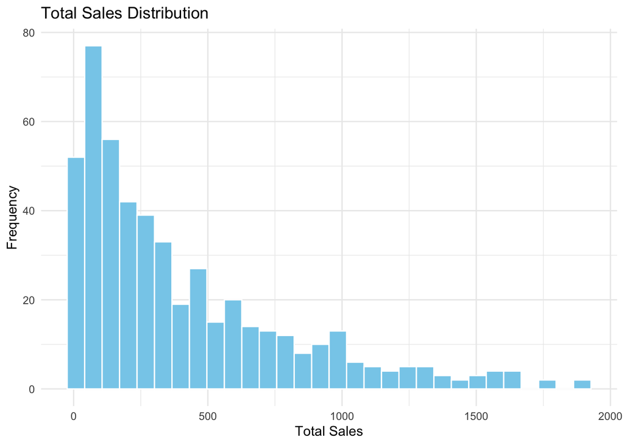

```r
ggplot(sales_cleaned, aes(x = sales_cleaned$TotalSales)) +
  geom_histogram(bins = 30, fill = "skyblue", color = "white") +
    labs(title = "Total Sales Distribution", x = "Total Sales", y = "Frequency") +
    theme_minimal()
```

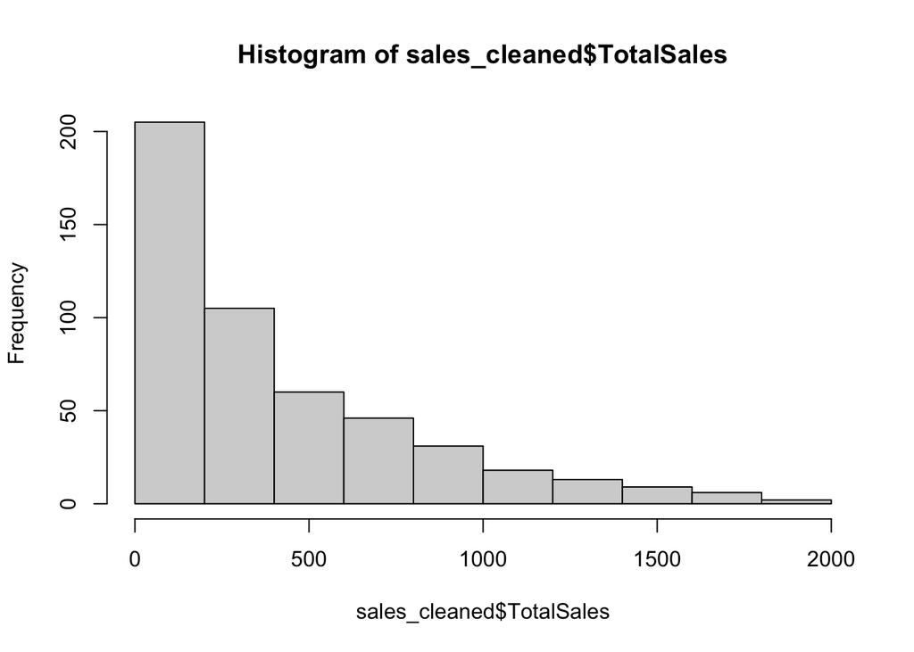

```r
hist(sales_cleaned$TotalSales)
```

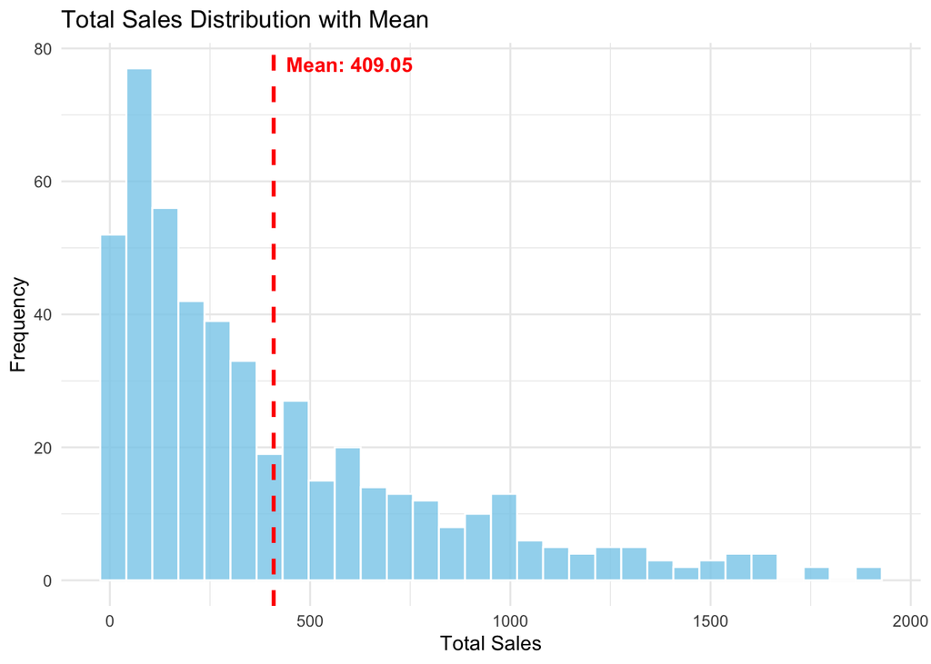

```r
# Calculate the mean
# mean_val <- mean(data$rainfall, na.rm = TRUE)

# Render the distribution with the mean overlaid
ggplot(sales_cleaned, aes(x = TotalSales)) +
  geom_histogram(bins = 30, fill = "skyblue", color = "white", alpha = 0.8) +
  geom_vline(aes(xintercept = mean_sales),
             color = "red", linetype = "dashed", linewidth = 1) +
  annotate("text", x = mean_sales, y = Inf, label = paste("Mean:", round(mean_sales, 2)),
           vjust = 2, hjust = -0.1, color = "red", fontface = "bold") +
  labs(
    title = "Total Sales Distribution with Mean",
    x = "Total Sales",
    y = "Frequency"
  ) +
  theme_minimal()
```

```r
paste0("Mean Unit Price: $", round(mean(sales_cleaned$UnitPrice), 2))
```

```
## [1] "Mean Unit Price: $52.41"
```

```r
paste0("Mean Quantity: ", round(mean(sales_cleaned$Quantity), 2))
```

```
## [1] "Mean Quantity: 9.59"
```

## 1.2 - Median

## 1.3 - Mode

# 2 - Measures of Dispersion

## 2.3 - Heteroscedasticity & Homooscedasticity

## 2.4 - Full Width at Half Maximum (FWHM)

## 2.5 - Fano Factor and Coefficient of Variation

## 2.6 - Interquartile Range

## 2.7 - QQ Plots

# 3 - Statistical Moments

# 4 - Histograms